# Modeling

```r
data <- readRDS(file=here("diab_cohort.rds"))
data
```

| BENE_ID | STATE | TIME_SINCE_PREDIAB | Obesity | Socioeconomic or lifestyle factors | Hypertension | Heart disease or failure | Sleep wake disorders | Alcohol-related disorders | Depressive or anxiety disorders | SEX_IDENT_CD | BENE_RACE_CD | AGE_CALC | AGE_GRP |
| --- | --- | --- | --- | --- | --- | --- | --- | --- | --- | --- | --- | --- | --- |
| -10000010288010 | 1 | 0 | 1 | 1 | 0 | 0 | 0 | 0 | 0 | 1 | 5 | 61 | ADULT BELOW 65 |
| -10000010288009 | 1 | 0 | 1 | 1 | 1 | 1 | 0 | 0 | 0 | 1 | 1 | 65 | ADULT 65+ |
| -10000010287992 | 1 | 0 | 0 | 0 | 0 | 0 | 0 | 0 | 0 | 1 | 1 | 83 | ADULT 65+ |
| -10000010287992 | 2 | 1 | 1 | 1 | 0 | 0 | 0 | 0 | 0 | 1 | 1 | 83 | ADULT 65+ |
| -10000010287992 | 2 | 2 | 1 | 1 | 0 | 1 | 0 | 0 | 0 | 1 | 1 | 83 | ADULT 65+ |
| -10000010287992 | 2 | 8 | 1 | 1 | 1 | 1 | 0 | 0 | 0 | 1 | 1 | 83 | ADULT 65+ |
| -10000010287992 | 2 | 10 | 1 | 1 | 1 | 1 | 1 | 0 | 0 | 1 | 1 | 83 | ADULT 65+ |
| -10000010287983 | 1 | 0 | 0 | 0 | 0 | 0 | 0 | 0 | 0 | 1 | 1 | 51 | ADULT BELOW 65 |
| -10000010287983 | 1 | 6 | 0 | 0 | 0 | 0 | 1 | 0 | 0 | 1 | 1 | 51 | ADULT BELOW 65 |
| -10000010287983 | 1 | 7 | 1 | 1 | 0 | 0 | 1 | 0 | 0 | 1 | 1 | 51 | ADULT BELOW 65 |

[output cut: 8209 more lines]

## 1 Kaplan Meier

- Here, we attempt to estimate survival probabilities; the probability that beneficiary has not yet made transition at any given time.
- For example, for a beneficiary with prediabetes (`state=1`), we want to estimate the probability that at time, say, 6 months, they still had prediabetes and hadn’t transitioned to any higher state.

```r
# time of first appearance in state 1 and time of next transition to state 2/3
survival_1 <- data %>%
  group_by(BENE_ID) %>%
  arrange(TIME_SINCE_PREDIAB) %>%
  filter(STATE %in% c(1, 2, 3)) %>%
  summarize(
    # (1) time at state=1 (value is 0 for all beneficiaries)
    # (2) find first/earliest time beneficiary transitions to state 2 or 3
    ##... ie., when did the beneficiary progress to either diabetes without/with complications?
    # (3) which state did beneficiary progress to ?
    start_time = TIME_SINCE_PREDIAB[which(STATE == 1)[1]],
    next_time = TIME_SINCE_PREDIAB[which(STATE %in% c(2, 3))[1]],
    next_state = STATE[which(STATE %in% c(2, 3))[which(STATE %in% c(2, 3)) > which(STATE == 1)[1]][1]]) %>%
  mutate(time_to_event = next_time - start_time,
         event = ifelse(!is.na(next_state), 1, 0)) %>%
  mutate(time_to_event = ifelse(is.na(time_to_event), max(time_to_event, na.rm=TRUE), time_to_event)) %>%
  arrange(desc(BENE_ID))

survival_1
```

| BENE_ID | start_time | next_time | next_state | time_to_event | event |
| --- | --- | --- | --- | --- | --- |
| -10000010288010 | 0 | NA | NA | 21 | 0 |
| -10000010288009 | 0 | NA | NA | 21 | 0 |
| -10000010287992 | 0 | 1 | 2 | 1 | 1 |
| -10000010287983 | 0 | NA | NA | 21 | 0 |
| -10000010287939 | 0 | NA | NA | 21 | 0 |
| -10000010287906 | 0 | NA | NA | 21 | 0 |
| -10000010287894 | 0 | 9 | 3 | 9 | 1 |
| -10000010287885 | 0 | 1 | 3 | 1 | 1 |
| -10000010287875 | 0 | NA | NA | 21 | 0 |
| -10000010287870 | 0 | NA | NA | 21 | 0 |

[output cut: 3162 more lines]

```r
# time of first appearance in state 2 and time of transition to state 3
survival_2 <- data %>%
  group_by(BENE_ID) %>%
  arrange(TIME_SINCE_PREDIAB) %>%
  filter(STATE %in% c(2, 3)) %>%
  summarize(
    # (1) time at state=2
    # (2) find first/earliest time beneficiary transitions to state 3
    ##... ie., when did the beneficiary progress to diabetes with complications?
    start_time = TIME_SINCE_PREDIAB[which(STATE == 2)[1]],
    next_time = TIME_SINCE_PREDIAB[which(STATE == 3)[1]],
    next_state = STATE[which(STATE == 3)[which(STATE == 3) > which(STATE == 2)[1]][1]]) %>%
  mutate(time_to_event = next_time - start_time,
         event = ifelse(!is.na(next_state), 1, 0)) %>%
  filter(!is.na(start_time)) %>% #filter out patients who never entered state 2
  mutate(time_to_event = ifelse(is.na(time_to_event), max(time_to_event, na.rm=TRUE), time_to_event)) %>%
  arrange(desc(BENE_ID))

survival_2
```

| BENE_ID | start_time | next_time | next_state | time_to_event | event |
| --- | --- | --- | --- | --- | --- |
| -10000010287992 | 1 | NA | NA | 15 | 0 |
| -10000010287686 | 3 | 5 | 3 | 2 | 1 |
| -10000010287111 | 5 | NA | NA | 15 | 0 |
| -10000010286911 | 9 | NA | NA | 15 | 0 |
| -10000010286856 | 7 | NA | NA | 15 | 0 |
| -10000010286773 | 6 | NA | NA | 15 | 0 |
| -10000010286641 | 4 | 5 | 3 | 1 | 1 |
| -10000010286409 | 4 | 5 | 3 | 1 | 1 |
| -10000010286214 | 3 | NA | NA | 15 | 0 |
| -10000010286128 | 3 | NA | NA | 15 | 0 |

[output cut: 170 more lines]

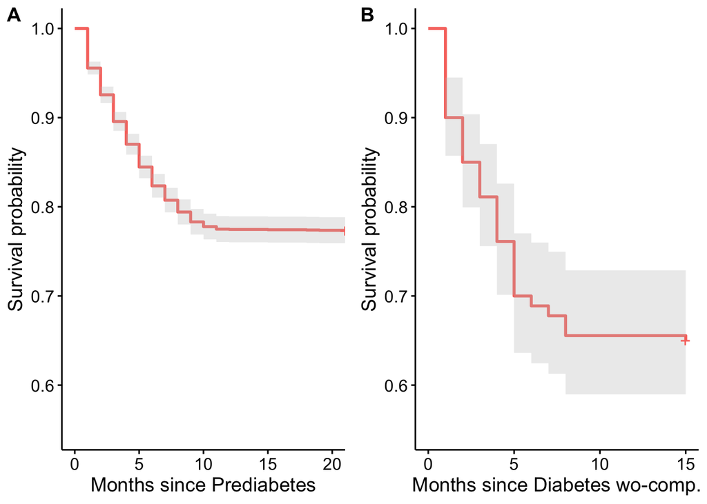

```r
# K-M curves
km_1 <- survfit(Surv(time_to_event, event) ~ 1, data = survival_1)
km_2 <- survfit(Surv(time_to_event, event) ~ 1, data = survival_2)

kmplot_1 <- ggsurvplot(
  km_1, conf.int = TRUE, surv.median.line = "hv", xlab = "Months since Prediabetes")$plot +
  theme(legend.position = "none") +
  scale_y_continuous(limits = c(0.55, 1))
kmplot_2 <- ggsurvplot(
  km_2, conf.int = TRUE, surv.median.line = "hv", xlab = "Months since Diabetes wo-comp.")$plot +
  theme(legend.position = "none") +
  scale_y_continuous(limits = c(0.55, 1))
combined_plot <- plot_grid(kmplot_1, kmplot_2, labels = c("A", "B"), ncol = 2)
combined_plot
```

## 2 Multi-state Modeling

### 2.1 Transition Probabilities

- Here, we estimate transition probabilities; the probability of being in a future state (or remain in same state) at given times, given that the patient was in that starting state.
- For example, we want to estimate the probability that a patient is with diabetes with complications (`state=3`) at time, say, 6 months, given that they had prediabetes at baseline.

$$P_{ij}(t) = Pr(\text{patient in
state}\,j\,\text{at time}\,t\, |\,\text{patient started in
state}\,i)$$
* We’ll compute these probabilities while adjusting for demographic factors (sex, race, age at baseline) and comorbidities (Obesity, Socioeconomic or lifestyle factors, Hypertension, Heart disease or failure, Sleep wake disorders, Alcohol-related disorders, Depressive or anxiety disorders).

- Refer to `R` package `msm` for fitting continuous-time **multi-state models**.

```r
Q <- rbind(c(0, 0.1, 0.1), # 1 to 2/3
           c(0, 0,   0.1), # 2 to 3
           c(0, 0,   0)) # 3 (absorbing state)

model <- msm(
  STATE ~ TIME_SINCE_PREDIAB, subject = BENE_ID,
  data = data, qmatrix = Q,
  covariates = ~ Obesity + `Socioeconomic or lifestyle factors` + Hypertension +
    `Heart disease or failure` +  `Sleep wake disorders` + `Alcohol-related disorders` +
    `Depressive or anxiety disorders` + SEX_IDENT_CD + BENE_RACE_CD + AGE_CALC,
  method = "BFGS")

pmatrix.msm(model, t=5)
```

```
##           State 1    State 2   State 3
## State 1 0.7623341 0.06459457 0.1730714
## State 2 0.0000000 0.64117862 0.3588214
## State 3 0.0000000 0.00000000 1.0000000
```

```r
times <- c(0:12, seq(15, max(data$TIME_SINCE_PREDIAB)+3, 3))

# transition probabilities
transition_state1 <- transition_state2 <- c()

for (tm in times) {
  transition_state1 <- rbind(transition_state1, as.vector(pmatrix.msm(model, t = tm)[1,]))
  transition_state2 <- rbind(transition_state2, as.vector(pmatrix.msm(model, t = tm)[2,2:3]))
}

colnames(transition_state1) <- c("State 1","State 2","State 3")
colnames(transition_state2) <- c("State 2","State 3")
rownames(transition_state1) <- rownames(transition_state2) <- times
#transition_state1
#transition_state2

tbl1 <- round(transition_state1, 3) %>%
  as.data.frame() %>%
  rownames_to_column(var = "Time (months)") %>%
  gt() %>%
  tab_source_note(md("Abbreviations: State 1 = Prediabetes,
                     State 2 = Diabetes mellitus without complication,
                     State 3 = Diabetes mellitus with complication")) %>%
  tab_header(md("**Transition Probabilities from Prediabetes**"))

tbl1
```

**Transition Probabilities from Prediabetes**

| Time (months) | State 1 | State 2 | State 3 |
| --- | --- | --- | --- |
| 0 | 1.000 | 0.000 | 0.000 |
| 1 | 0.947 | 0.017 | 0.036 |
| 2 | 0.897 | 0.032 | 0.071 |
| 3 | 0.850 | 0.045 | 0.106 |
| 4 | 0.805 | 0.055 | 0.140 |
| 5 | 0.762 | 0.065 | 0.173 |
| 6 | 0.722 | 0.072 | 0.206 |
| 7 | 0.684 | 0.078 | 0.238 |
| 8 | 0.648 | 0.084 | 0.269 |
| 9 | 0.614 | 0.088 | 0.299 |
| 10 | 0.581 | 0.091 | 0.328 |
| 11 | 0.550 | 0.093 | 0.357 |
| 12 | 0.521 | 0.094 | 0.384 |
| 15 | 0.443 | 0.096 | 0.461 |
| 18 | 0.376 | 0.093 | 0.530 |
| 21 | 0.320 | 0.088 | 0.592 |
| 24 | 0.272 | 0.082 | 0.646 |

Abbreviations: State 1 = Prediabetes, State 2 = Diabetes mellitus without complication, State 3 = Diabetes mellitus with complication

```r
tbl2 <- round(transition_state2, 3) %>%
  as.data.frame(transition_state2) %>%
  rownames_to_column(var = "Time (months)") %>%
  gt()%>%
  tab_source_note(md("Abbreviations: State 1 = Prediabetes,
                     State 2 = Diabetes mellitus without complication,
                     State 3 = Diabetes mellitus with complication")) %>%
  tab_header(md("**Transition Probabilities from Diabetes without Complications**"))

tbl2
```

**Transition Probabilities from Diabetes without Complications**

[output not shown]

Abbreviations: State 1 = Prediabetes, State 2 = Diabetes mellitus without complication, State 3 = Diabetes mellitus with complication

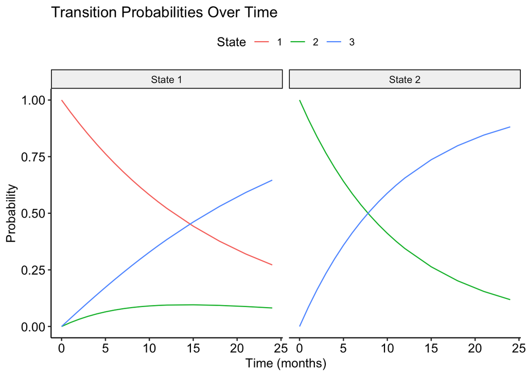

```r
# transition probability curves
transition_state1_curve <- as.data.frame(transition_state1) %>%
  rownames_to_column(var = "time") %>%
  mutate(trns_from = "State 1")

transition_state2_curve <- as.data.frame(transition_state2) %>%
  rownames_to_column(var = "time") %>%
  mutate(`State 1` = NA, trns_from = "State 2") %>%
  select(time, `State 1`, `State 2`, `State 3`, trns_from)

transition_curve <- rbind(transition_state1_curve, transition_state2_curve) %>%
  mutate(time = as.numeric(time)) %>%
  pivot_longer(cols = starts_with("State"), names_to = "State", values_to = "prob") %>%
  mutate(State = stringr::str_sub(State, 7)) %>%
  ggplot(., aes(x = time, y = prob, color = State)) +
  geom_line() +
  facet_wrap(trns_from ~., nrow = 1) +
  labs(x="Time (months)", y="Probability", title="Transition Probabilities Over Time") +
  theme_pubr()

transition_curve
```

### 2.2 Covariate Effects across Diabetes States

```r
# get HRs and CIs
hrs <- hazard.msm(model)
hrs$Obesity
```

```
##                         HR         L        U
## State 1 - State 2 1.287769 0.9491470 1.747199
## State 1 - State 3 1.663086 1.3787895 2.006001
## State 2 - State 3 1.412111 0.8274826 2.409786
```

```r
## just a little function to summarize HR output into format: HR (L, U)
# hr_format <- function(covariate) {
#   apply(covariate, 1, function(x) {
#     x = round(x, 3); return(paste0(x[1], " (", x[2], ", ", x[3], ")"))})}

hr_format <- function(covariate) {
  apply(covariate, 1, function(x, M=1e+6) {
    x <- round(x, 3)
    if (x[3] < M) {return(paste0(x[1], " (", x[2], ", ", x[3], ")"))}
    else {return(paste0(x[1], " (", x[2], ", ", Inf, ")"))}
    })}

hrs <- lapply(hrs, hr_format)
hr_summary <- do.call(rbind, hrs)
colnames(hr_summary) <- c("1-2","1-3","2-3")
rownames(hr_summary) <- c(names(data)[4:10], "Sex", "Race", "Age (years)")

hr_summary <- as.data.frame(hr_summary) %>%
  rownames_to_column(var = "Covariate") %>%
  gt()%>%
  tab_source_note(md("1 = Prediabetes,
                     2 = Diabetes mellitus without complication,
                     3 = Diabetes mellitus with complication")) %>%
  tab_header(md("**Estimated Effect per Transition**"))

hr_summary
```

**Estimated Effect per Transition**

| Covariate | 1-2 | 1-3 | 2-3 |
| --- | --- | --- | --- |
| Obesity | 1.288 (0.949, 1.747) | 1.663 (1.379, 2.006) | 1.412 (0.827, 2.41) |
| Socioeconomic or lifestyle factors | 1.366 (1.006, 1.854) | 2.239 (1.835, 2.733) | 1.396 (0.805, 2.422) |
| Hypertension | 2 (1.449, 2.761) | 4.808 (3.968, 5.825) | 1.962 (1.136, 3.388) |
| Heart disease or failure | 1.993 (1.435, 2.769) | 1.497 (1.213, 1.848) | 1.588 (0.918, 2.747) |
| Sleep wake disorders | 0.525 (0.273, 1.008) | 0.957 (0.717, 1.279) | 0.507 (0.206, 1.247) |
| Alcohol-related disorders | 1.325 (0.502, 3.495) | 1.382 (0.853, 2.238) | 2.171 (0.423, 11.134) |
| Depressive or anxiety disorders | 1.71 (0.765, 3.824) | 2.185 (1.469, 3.249) | 1.849 (0.58, 5.894) |
| Sex | 1.015 (0.749, 1.375) | 0.797 (0.658, 0.965) | 0.802 (0.471, 1.364) |
| Race | 1.002 (0.91, 1.102) | 1.02 (0.963, 1.082) | 1.078 (0.916, 1.269) |
| Age (years) | 1.014 (1.002, 1.026) | 1.003 (0.996, 1.011) | 1.044 (1.02, 1.068) |

1 = Prediabetes, 2 = Diabetes mellitus without complication, 3 = Diabetes mellitus with complication